# Multiple Linear Regression - TP 5 & 6

Emily Schmidt

2022-11-04

## Load Packages and Data

```r
library(data.table) # Fast aggregation of large data sets and a fast file reader
library(lubridate) # Commute date-times
library(ggplot2) # Provides helpful commands to create complex plots from data in a data frame
library(robust) # Compute an analysis of variance table for one or more robust generalized linear model fits.
library(ellipse) # Contains various routines for drawing ellipses and ellipse-like confidence regions
library(plotly) # Makes interactive, publication-quality graphs
library(GGally) # Allows to build a great scatterplot matrix
library(tidyr) # Can be used to “gather” a key-value pair across multiple columns
library(cowplot) # Arrange plots into a grid and label them
library(kableExtra)  # Tables
require(robust)
```

```r
setwd("C:\\Users\\emann\\R Data Files") # Set directory
getwd() # Check the working directory
```

```
## [1] "C:/Users/emann/R Data Files"
```

```r
CoursEval = read.csv("CoursEval.csv")
conso = read.table("conso.txt", header=TRUE)
ciga = read.table("ciga.txt", header=TRUE)

source("VIF.R")
source("PlotResidX.R")
source("R2wRob.R")
```

# Exercises & Overall Questions

Fit a linear regression model for each of the data set conso and ciga, including the Exploratory Data Analysis (EDA) and by progressively answering the questions below. Please fully complete the analysis for each data set a time.  
**1.** *For the data sets conso and ciga compute the variance inflation factors, perform the different multiple linear regression estimations and comment the results.*  
**2.** *Perform the residuals analysis for the data sets conso and ciga. By performing the residuals analysis do you consider the models to be valid or not?*  
**3.** *For all the data sets analysed, i.e. for conso and ciga, answer the following questions:*

**A.** *What are the estimated values for the βj s using classic (LS) and robust (M-estimation) estimation?*  
**B.** *How do you interpret them?*  
**C.** *Are the parameters significant?*  
**D.** *How large are the R2s for your models (classic and robust)? How do you interpret them?*  
**E.** *How do you interpret the ‘Test of Bias’ results?*

# Conso

## Exploratory Data Analysis

```r
dim(conso) # Get or set the dimension of the specified matrix, array or data frame
```

```
## [1] 48  7
```

```r
kable(head(conso)) %>% kable_classic() %>%
  kableExtra::kable_styling(bootstrap_options = c("striped", "hover", "condensed","responsive")) %>%
  kable_styling(position = "center") # Use kable to design table
```

| ID | const | tax | income | paved | license | consumption |
| --- | --- | --- | --- | --- | --- | --- |
| 1 | 1 | 9.0 | 3571 | 1976 | 0.525 | 541 |
| 2 | 1 | 9.0 | 4092 | 1250 | 0.572 | 524 |
| 3 | 1 | 9.0 | 3865 | 1586 | 0.580 | 561 |
| 4 | 1 | 7.5 | 4870 | 2351 | 0.529 | 414 |
| 5 | 1 | 8.0 | 4399 | 431 | 0.544 | 410 |
| 6 | 1 | 10.0 | 5342 | 1333 | 0.571 | 457 |

```r
View(conso) # Invoke a spreadsheet-style data viewer within RStudio
str(conso) # Compactly displaying the internal structure of a R object
```

```
## 'data.frame':    48 obs. of  7 variables:
##  $ ID         : int  1 2 3 4 5 6 7 8 9 10 ...
##  $ const      : int  1 1 1 1 1 1 1 1 1 1 ...
##  $ tax        : num  9 9 9 7.5 8 10 8 8 8 7 ...
##  $ income     : int  3571 4092 3865 4870 4399 5342 5319 5126 4447 4512 ...
##  $ paved      : int  1976 1250 1586 2351 431 1333 11868 2138 8577 8507 ...
##  $ license    : num  0.525 0.572 0.58 0.529 0.544 0.571 0.451 0.553 0.529 0.552 ...
##  $ consumption: int  541 524 561 414 410 457 344 467 464 498 ...
```

```r
which(is.na(conso)) # Function returns the positions with missing values
```

```
## integer(0)
```

```r
Conso = conso[,(3:7)] # Calls only certain columns into the dataset by reassignment
kable(head(Conso)) %>% kable_classic() %>%
  kableExtra::kable_styling(bootstrap_options = c("striped", "hover", "condensed","responsive")) %>%
  kable_styling(position = "center") # Use kable to design table
```

| tax | income | paved | license | consumption |
| --- | --- | --- | --- | --- |
| 9.0 | 3571 | 1976 | 0.525 | 541 |
| 9.0 | 4092 | 1250 | 0.572 | 524 |
| 9.0 | 3865 | 1586 | 0.580 | 561 |
| 7.5 | 4870 | 2351 | 0.529 | 414 |
| 8.0 | 4399 | 431 | 0.544 | 410 |
| 10.0 | 5342 | 1333 | 0.571 | 457 |

```r
# Produce result summaries
CSUM <- data.frame(mean = sapply(Conso[,c(1:5)], mean,na.rm = T)
                ,median = sapply(Conso[,c(1:5)], median,na.rm = T)
                ,min = sapply(Conso[,c(1:5)], min,na.rm = T)
                ,max = sapply(Conso[,c(1:5)], max,na.rm = T)
                ,sd = sapply(Conso[,c(1:5)], sd,na.rm = T))
colnames(CSUM) = c("Mean","Median","Min","Max","Standard Deviation")
kable(head(CSUM)) %>% kable_classic() %>%
  kableExtra::kable_styling(bootstrap_options = c("striped", "hover", "condensed","responsive")) %>%
  kable_styling(position = "center") # Use kable to design table
```

|  | Mean | Median | Min | Max | Standard Deviation |
| --- | --- | --- | --- | --- | --- |
| tax | 7.6683333 | 7.5000 | 5.000 | 10.000 | 0.9507698 |
| income | 4241.8333333 | 4298.0000 | 3063.000 | 5342.000 | 573.6237678 |
| paved | 5565.4166667 | 4735.5000 | 431.000 | 17782.000 | 3491.5071661 |
| license | 0.5703333 | 0.5645 | 0.451 | 0.724 | 0.0554703 |
| consumption | 576.7708333 | 568.5000 | 344.000 | 968.000 | 111.8858156 |

To kick off our analysis, we must review our data to ensure that we understand what we are looking at prior to building our model. There are several key observations that I would like to discuss:  
1. There are 48 observations, and 7 variables. Out of those seven values, you will notice that we have we have two variables that are not necessarily needed (‘ID’ country and ‘const’, which is a vector of 1). Therefore, we remove those from our data.  
2. Are there missing values? No.  
3. Within the summary table, we notice that income, paved, and license all have large variances. Additionally, when we compare the median and mean of each variable, one can assume that most of the parameters are fairly balanced, or symmetric on each side. The one value that we need to watch out for is paved, as the two measures are not as close. We will continue our analysis to examine if we need to transform.

```r
Conso %>% gather() %>% head() # Reshaping the data which means it collects a set of column names and places them into a single “key” column
```

```
##   key value
## 1 tax   9.0
## 2 tax   9.0
## 3 tax   9.0
## 4 tax   7.5
## 5 tax   8.0
## 6 tax  10.0
```

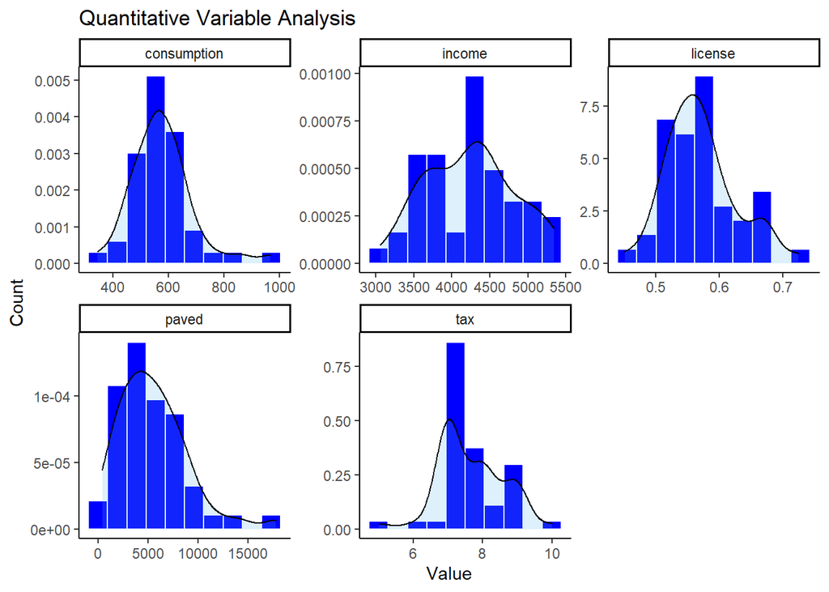

```r
histograms <- ggplot(gather(data = Conso),aes(value)) +
  geom_histogram(aes(y=..density..),bins = 10, color = "white", fill = "blue") + # Creates bin sizing and sets the lines as white
  geom_density(alpha= .2, fill="#56B4E9") +
  facet_wrap(~key,scales = "free") + # Converting the graphs into panels
  ggtitle("Quantitative Variable Analysis") + # Title name
  ylab("Count") + xlab("Value") + # Label names
  theme_classic() # A classic theme, with x and y axis lines and no grid lines

histograms
```

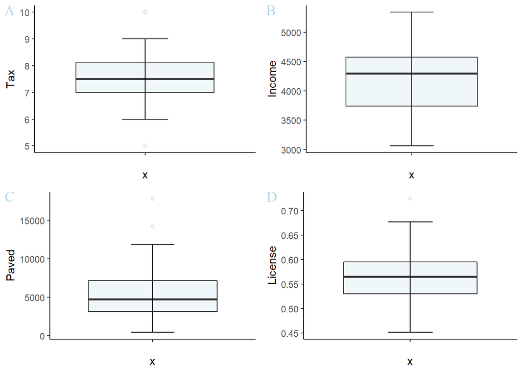

```r
# Using ggplot to creat various boxplots with various features
tax.box <- ggplot(data = Conso, aes(x="",y= tax)) +
    geom_boxplot(fill="lightblue", alpha=0.2, outlier.shape = 21, outlier.color = "black") +
    stat_boxplot(geom='errorbar', linetype=1, width=0.25) +
    ylab("Tax") + # Label names
    theme_classic() # A classic theme, no grid lines

income.box <- ggplot(data = Conso, aes(x="",y= income)) +
    geom_boxplot(fill="lightblue", alpha=0.2, outlier.shape = 21, outlier.color = "black") +
    stat_boxplot(geom='errorbar', linetype=1, width=0.25) +
    ylab("Income") + # Label names
    theme_classic() # A classic theme, no grid lines

paved.box <- ggplot(data = Conso, aes(x="",y= paved)) +
    geom_boxplot(fill="lightblue", alpha=0.2, outlier.shape = 21, outlier.color = "black") +
    stat_boxplot(geom='errorbar', linetype=1, width=0.25) +
    ylab("Paved") + # Label names
    theme_classic() # A classic theme, no grid lines

license.box <- ggplot(data = Conso, aes(x="",y= license)) +
    geom_boxplot(fill="lightblue", alpha=0.2, outlier.shape = 21, outlier.color = "black") +
    stat_boxplot(geom='errorbar', linetype=1, width=0.25) +
    ylab("License") + # Label names
    theme_classic() # A classic theme, no grid lines

# Places the graphs into one space
plot_grid(tax.box, income.box, paved.box, license.box, labels = "AUTO",
  label_fontfamily = "serif",
  label_fontface = "plain",
  label_colour = "lightblue")
```

Throughout this EDA, we will primarily focus on two variable groups: explanatory (x) and response (y).

If we consider the histograms of all variables and the boxplots for the explanatory values, one can notice that these values are not perfectly symmetrical. One has to be aware that there is no extreme deviation. This can also be seen from our analysis of the means vs medians. We must consider that there are outliers present within ‘tax’, ‘paved’, and ‘license’. At this point, we will not conduct further testing as it is too early to see if those data points influence our overall results. From the comment about possibly transforming the ‘paved’ variable, we will leave it as is since the distribution is close to normal.

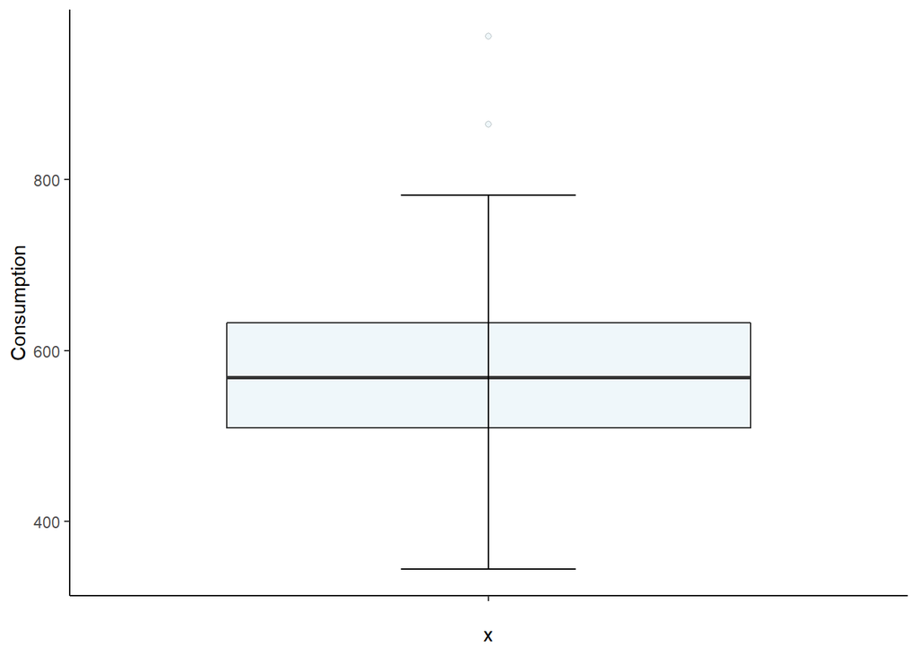

```r
# Crate boxplot from ggplot with different features
ggplot(data = Conso, aes(x="", y= consumption)) +
    geom_boxplot(fill="lightblue", alpha=0.2, outlier.shape = 21, outlier.color = "black") +
    stat_boxplot(geom='errorbar', linetype=1, width=0.25) +
    ylab("Consumption") + # Label names
    theme_classic() # A classic theme, no grid lines
```

In the graphs above, we primarily focused on the explanatory variables. Here, we dive into our response, ‘consumption’. Other than the two outliers present, the boxplot matches the assumptions from above that the mean and median are almost identical (difference of ~8.28), and the histogram skews slightly right (positive) but appears to have an overall normal distribution.

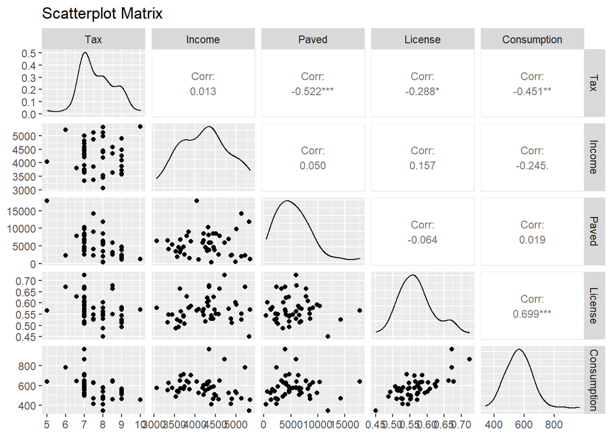

```r
# Used ggpairs to create a scatterplot matrix
scaterrplot <- ggpairs(Conso, title = "Scatterplot Matrix",
                      columns = 1:5,
                      proportions = "auto",
                      columnLabels = c("Tax","Income","Paved",
                      "License","Consumption"),
                      upper = list(continuous = wrap('cor',size = 3)),)

scaterrplot
```

```r
cormat <- round(cor(Conso),2) # Round the correlation coefficient to two decimal places

melted_cormat <- melt(cormat) # One way to reshape and elongate the data frame

# Get upper triangle of the correlation matrix
  get_upper_tri <- function(cormat){
    cormat[lower.tri(cormat)]<- NA
    return(cormat)
  }

# Rename the correlation coefficient value
upper_tri <- get_upper_tri(cormat)
upper_tri
```

```
##             tax income paved license consumption
## tax           1   0.01 -0.52   -0.29       -0.45
## income       NA   1.00  0.05    0.16       -0.24
## paved        NA     NA  1.00   -0.06        0.02
## license      NA     NA    NA    1.00        0.70
## consumption  NA     NA    NA      NA        1.00
```

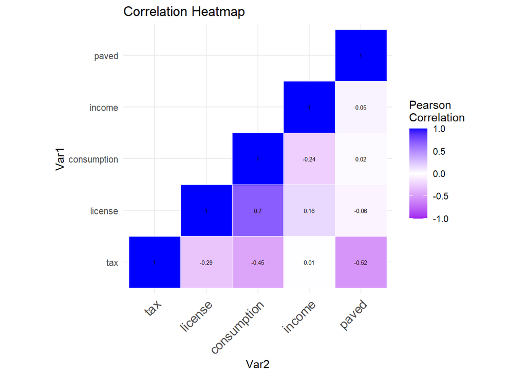

```r
# Use correlation between variables as distance
reorder_cormat <- function(cormat){
dd <- as.dist((1-cormat)/2)
hc <- hclust(dd)
cormat <-cormat[hc$order, hc$order]
}

# Reorder the correlation matrix
cormat <- reorder_cormat(cormat)
upper_tri <- get_upper_tri(cormat)

# Melt the correlation matrix
melted_cormat <- melt(upper_tri, na.rm = TRUE)

# Create a ggheatmap with multiple characteristics
ggheatmap <- ggplot(melted_cormat, aes(Var2, Var1, fill = value)) +
  geom_tile(color = "white") +
  scale_fill_gradient2(low = "purple", high = "blue", mid = "white", midpoint = 0, limit = c(-1,1), space = "Lab", name="Pearson\nCorrelation") +
  ggtitle("Correlation Heatmap") + # Title name
  theme_minimal() + # Minimal theme, keeps in the lines
  theme(axis.text.x = element_text(angle = 45, vjust = 1, size = 12, hjust = 1)) +
  coord_fixed() +
  geom_text(aes(Var2, Var1, label = value), color = "black", size = 2)

# Print the heat map
print(ggheatmap)
```

As we discussed in class, one possible issue we want to avoid is non independence of the explanatory variables, or multicollinearity. To detect this issue, we must look at variance inflation factors symbolized by VIF.

## Variance Inflation Factors

```r
VIF(Conso[,1:4], Conso[,5]) # Call VIF from the source
```

```
##
##     tax  income   paved license
## 1.62568 1.04327 1.49694 1.21636
##
##   Mean: 1.34556
```

To properly analyze the results in the table above, we need to ensure that the variables to not exceed the average of VIF. Multicollinearity is present when certain VIF are larger than 5 or 10. None of the variables show signs of multicollinearity. Therefore, we can conclude we do not have to do a model selection.

### Ordinary Least Squares Estimation (LS)

```r
# Fit linear models to data frames
Conso.ls = lm(consumption ~ ., data = Conso)

summary(Conso.ls)
```

```
##
## Call:
## lm(formula = consumption ~ ., data = Conso)
##
## Residuals:
##     Min      1Q  Median      3Q     Max
## -122.03  -45.57  -10.66   31.53  234.95
##
## Coefficients:
##               Estimate Std. Error t value Pr(>|t|)
## (Intercept)  3.773e+02  1.855e+02   2.033 0.048207 *
## tax         -3.479e+01  1.297e+01  -2.682 0.010332 *
## income      -6.659e-02  1.722e-02  -3.867 0.000368 ***
## paved       -2.426e-03  3.389e-03  -0.716 0.477999
## license      1.336e+03  1.923e+02   6.950 1.52e-08 ***
## ---
## Signif. codes:  0 '***' 0.001 '**' 0.01 '*' 0.05 '.' 0.1 ' ' 1
##
## Residual standard error: 66.31 on 43 degrees of freedom
## Multiple R-squared:  0.6787, Adjusted R-squared:  0.6488
## F-statistic: 22.71 on 4 and 43 DF,  p-value: 3.907e-10
```

For the classical LS model, we will review the four explanatory variables. In the output above, it is evident that ‘paved’ is not significant as the p-value exceeds α = 0.05. There is not enough evidence and therefore, we fail to reject the null hypothesis (H0: β0 = 0). If we proceed with the other three variables, we can assume that ‘tax’, ‘income’, and ‘license’ explains most of ‘consumption’ (response variable, y).

As we discussed in the lecture, we need to also calculate the degrees of freedom. For this exercise, we have 48 observations minus the four exploratory variables. The intercept needs to be accounted for as well, which equates to 1. To get 43 degrees of freedom, the equation would be the following: 48 - 4 - 1 = 43.

F-stat is significant, and therefore, we reject the null hypothesis since α = 0.05. A model is qualitatively good if the Fisher test is signifigant an R-squared big.  
- (H0: β1 = β2 = β3 = β4)

### M-estimation at 90% efficiency

```r
# Fit robust linear models to data frames
Conso.m90 = lmRob(consumption ~ . , data = Conso)

summary(Conso.m90)
```

```
##
## Call:
## lmRob(formula = consumption ~ ., data = Conso)
##
## Residuals:
##     Min      1Q  Median      3Q     Max
## -98.508 -26.779   1.898  28.229 311.952
##
## Coefficients:
##               Estimate Std. Error t value Pr(>|t|)
## (Intercept) 456.730208 165.824837   2.754  0.00859 **
## tax         -15.937399  11.856438  -1.344  0.18593
## income       -0.076470   0.014925  -5.124 6.74e-06 ***
## paved         0.001821   0.003024   0.602  0.55028
## license     946.474273 180.986740   5.230 4.76e-06 ***
## ---
## Signif. codes:  0 '***' 0.001 '**' 0.01 '*' 0.05 '.' 0.1 ' ' 1
##
## Residual standard error: 45.52 on 43 degrees of freedom
## Multiple R-Squared: 0.5185
##
## Test for Bias:
##             statistic p-value
## M-estimate      1.948  0.8563
## LS-estimate     4.817  0.4386
```

```r
R2wRob(Conso.m90)
```

```
##
## lmRob with 90% efficiency (c=3.88075)
##
## Robust multiple R-squared: 0.780001, Robust adjusted R-squared: 0.75381
```

In the multiple linear regression model, there are now two explanatory variables that are not significant at α = 0.05. Since the p-values of ‘tax’ and ‘paved’ are greater than alpha, we fail to reject the null hypothesis (H0: β0 = 0).

Just as before in the classical LS model, we need to calculate the degrees of freedom. For this exercise, we have 48 observations minus the four exploratory variables. The intercept needs to be accounted for as well, which equates to 1. To get 43 degrees of freedom, the equation would be the following: 48 - 4 - 1 = 43.

## Residual Analysis

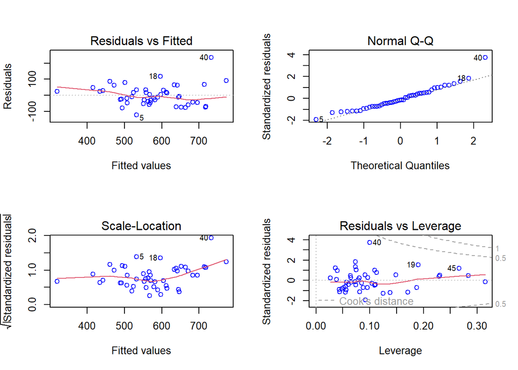

```r
par(mfrow = c(2,2)) # Organizes graphs in a specific order
plot(Conso.ls, col = "blue") # Plots the linear regression
```

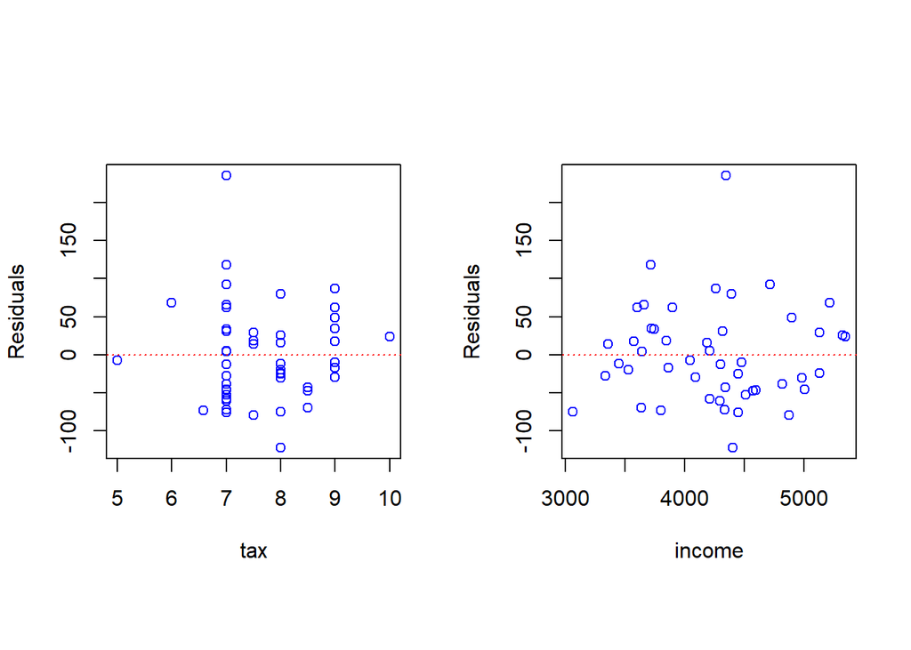

```r
par(mfrow = c(1,4)) # Organizes graphs in a specific order
PlotResidX(Conso[, 1:2], Conso.ls$residuals, col= "blue") # Creates the residuals plots and utilized color
```

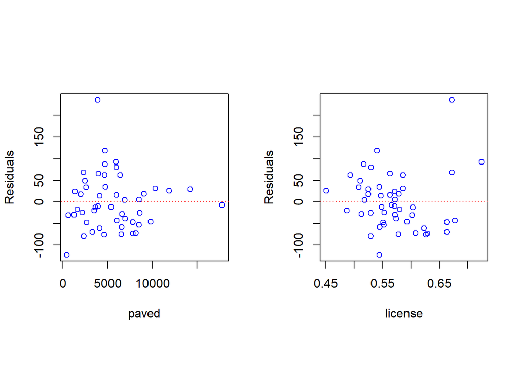

```r
PlotResidX(Conso[, 3:4], Conso.ls$residuals, col= "blue")
```

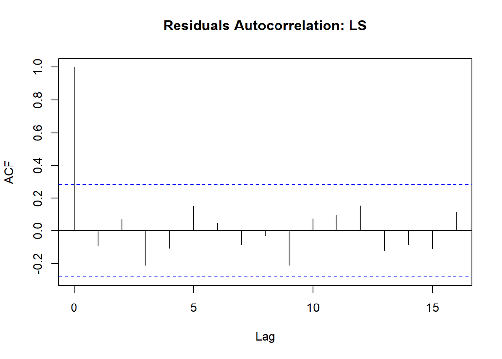

```r
# Function to graph autocorrelations
acf(resid(Conso.ls), main="Residuals Autocorrelation: LS")
```

**Residuals vs Fitted**  
With any model, the residuals should assume the following:  
1. ± as many negatives as positives (values), distributed around zero  
2. No structure  
3. No extreme values  
To ensure this criteria is met, we use the Residuals vs Fitted to check the lack of structure or presence of extreme values. It is important to note the following:  
- A residual will be considered large if its absolute value exceeds (approximately) 2σ(hat)  
- When n is large, a residual will be considered large if its absolute value exceeds (approximately) 4σ(hat) (otherwise, too many residues will be considered large!)

All values are weighted evenly in an LS model, including potential outliers. As mentioned above, we need to ensure that the residuals are within our limits. Referring back to the summary(Conso.ls) output, the model’s residual standard error is 66.31. If we multiple by ±2, we return our estimate. In this case, let us focus on the upper limit of 132.62. Visually, we can determine that the point ‘40’, falls outside that of 132.62 and would be considered large. Even though there one extreme, the residuals seem to follow the other two criteria above. Additionally, I would like to point out that the constant variance assumption is assumed to be violated since that the residuals have a wide range.

**Normal Q-Q**  
To check the normality of the errors εi we do a normal Q-Q plot of the residuals. For this graph, we can use the “thickness of a pencil approach.” If we were to put the pencil on the regression line, it is immediately noticed that the data point ‘40’ is not underneath. If we did not consider that extreme value, the Q-Q plot seems to be normally distributed minus the small departure at the tail part.

**Scale-Location**  
As seen in the other graphs, there is an extreme residual. We know that this is considered extreme because of the following: 2xσ.

**Autocorrelation**  
The ACF plot shows that there is no evidence of autocorrelation between the residuals.

From the information gathered above, we can conclude that we would not use the LS model due to it did not meeting the criteria of no extreme values.

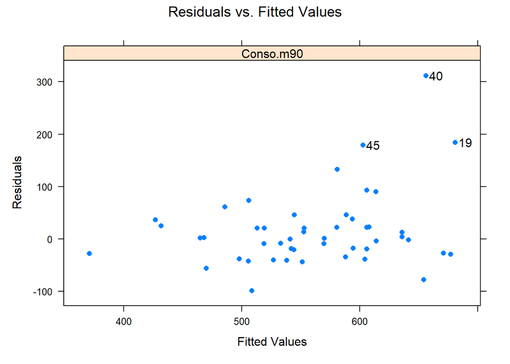

```r
# Plot the residuals of a robust model
plot.lmRob(Conso.m90, which.plots=4, id.n=10, col = "blue")
```

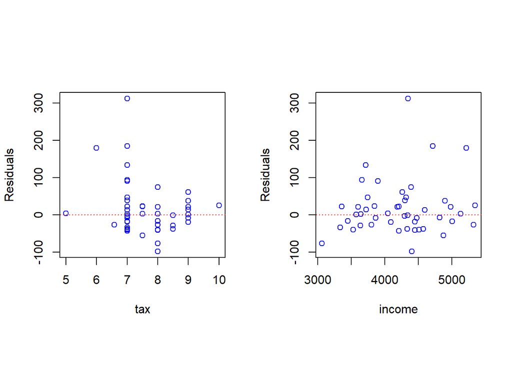

```r
par(mfrow = c(1,4)) # Specify the designation of charts
PlotResidX(Conso[, 1:2], Conso.m90$residuals, col= "blue") # Graphs the residuals
```

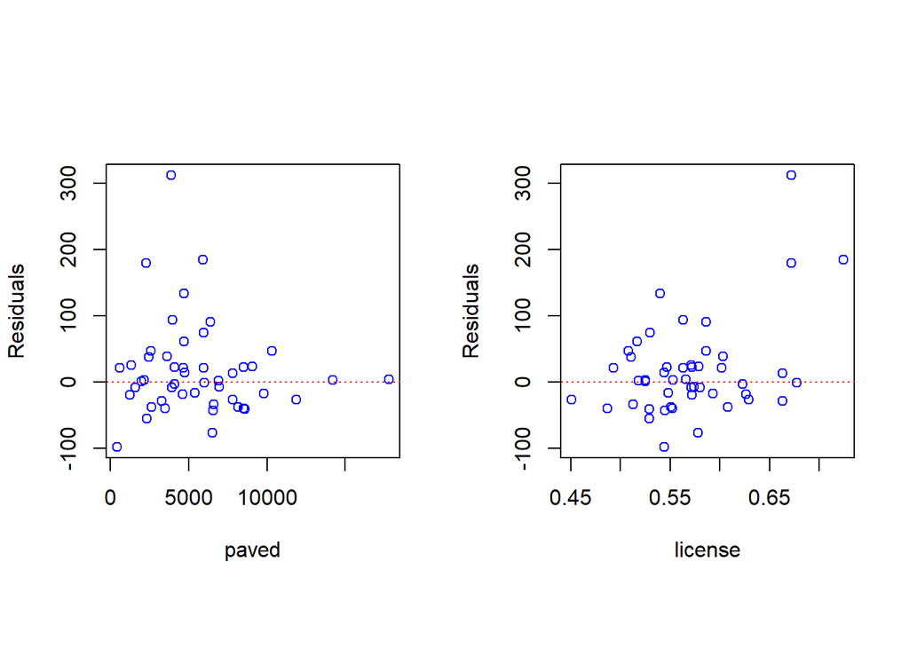

```r
PlotResidX(Conso[, 3:4], Conso.m90$residuals, col= "blue")
```

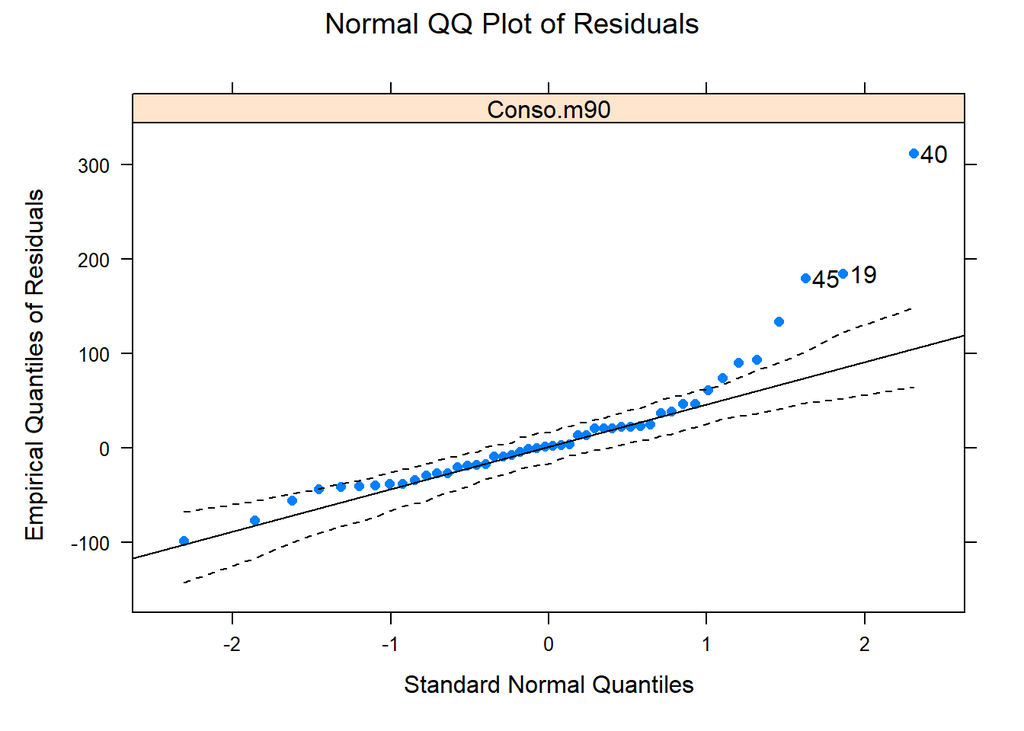

```r
# Plots the Q-Q plot for the robust regression model
plot.lmRob(Conso.m90, which.plots=1, id.n=10, envelope=FALSE, col = "blue")
```

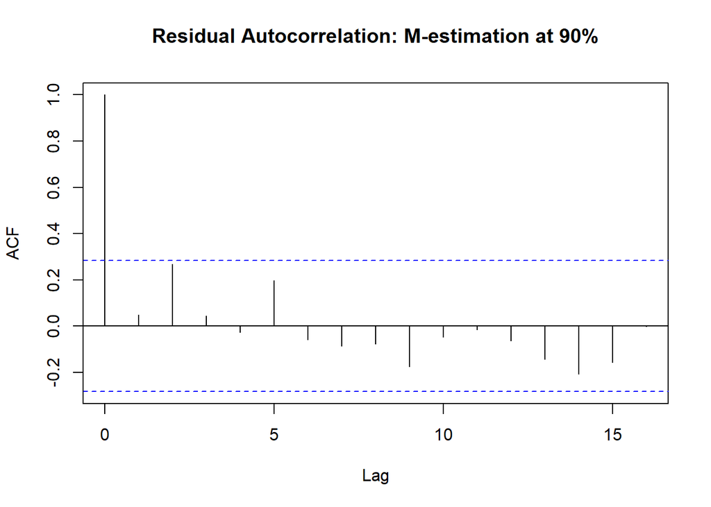

```r
# Function to graph autocorrelations
acf(resid(Conso.m90), main = "Residual Autocorrelation: M-estimation at 90%")
```

Unlike the classic LS model, we will say our conclusion first. Based off of the assumptions below, we will validate our M-estimation at 90% efficiency model. Here is why:

**Residuals vs Fitted**  
With any model, the residuals should assume the following:  
1. ± as many negatives as positives (values), distributed around zero  
2. No structure  
3. No extreme values  
To ensure this criteria is met, we use the Residuals vs Fitted to check the lack of structure or presence of extreme values. It is important to note the following:  
- A residual will be considered large if its absolute value exceeds (approximately) 2σ(hat)  
- When n is large, a residual will be considered large if its absolute value exceeds (approximately) 4σ(hat) (otherwise, too many residues will be considered large!)

**Normal Q-Q**  
To check the normality of the errors εi we do a normal Q-Q plot of the residuals. For this graph, we can approach the M-estimator model as we did with LS. In this Q-Q plot, there is a slight difference with the graph outcome. This time, we notice that there are three values that seem to depart by the tail. Otherwise, Q-Q plot seems to be normally distributed.

**Autocorrelation**  
The ACF plot shows that there is no evidence of autocorrelation between the residuals as it does not exceed the confidence interval.

As stated above, we assume that criteria are met due to the following:  
- Normal distribution (QQ plot)  
- The robust adjusted R-squared improved to 0.75381 compared to LS’ 0.6488  
- No sign of autocorrelation

## Conclusion

We need to consider which model is a better overall fit: LS or M-estimation. The following reasons indicate why one an analyst would choose one over the other:

#### Ordinary Least Squares Estimation (LS)

Advantages: efficient and unbiased estimators (in a finite sample)  
Disadvantage: model is very sensitive to deviations (i.e. extreme values) from hypothesis

#### M-estimator at 90% efficiency

From our LS analysis, we are aware of the extreme value at ‘40’. Therefore, choosing LS would not be the best method. Unlike the LS model, the resulting M-estimator is convergent, robust and the loss of efficiency is less as it can be controlled. Plus, we know that the adjusted R-squared is higher. We need to watch out for the degree of efficiency because as c decreases, the M-estimator will be more resistant to extreme values. To exemplify this, I demonstrate below how the models differ and to show how we could make a model (60% efficiency) less efficient.

The graph below represents each explanatory variable’s various regression lines and how the models handle extreme values.

Model 1 = LS Estimator

Model 2 = M-estimator at 90%

Model 3 = M-estimator at 60%

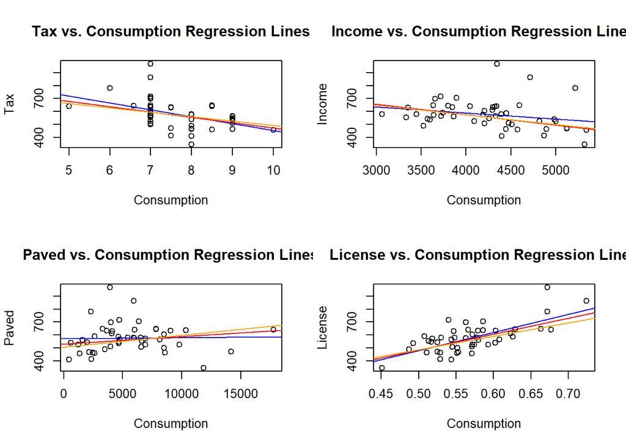

```r
# Creates various linear regression models and compares graphically

par(mfrow=c(2,2))

plot(Conso$tax,Conso$consumption, main="Tax vs. Consumption Regression Lines", xlab = "Consumption", ylab = "Tax")
abline(lm(Conso$consumption ~ Conso$tax), col="blue")
abline (lmRob(consumption ~ tax , data=Conso), col="red")
abline (lmRob(consumption ~ tax , data=Conso,control=lmRob.control(efficiency=0.60)), col="orange")

plot(Conso$income,Conso$consumption, main="Income vs. Consumption Regression Lines", xlab = "Consumption", ylab = "Income")
abline(lm(Conso$consumption ~ Conso$income), col="blue")
abline (lmRob(consumption ~ income , data=Conso), col="red")
abline (lmRob(consumption ~ income , data=Conso,control=lmRob.control(efficiency=0.60)), col="orange")

plot(Conso$paved,Conso$consumption, main="Paved vs. Consumption Regression Lines", xlab = "Consumption", ylab = "Paved")
abline(lm(Conso$consumption ~ Conso$paved), col="blue")
abline (lmRob(consumption ~ paved , data=Conso), col="red")
abline (lmRob(consumption ~ paved , data=Conso,control=lmRob.control(efficiency=0.60)), col="orange")

plot(Conso$license,Conso$consumption, main="License vs. Consumption Regression Lines", xlab = "Consumption", ylab = "License")
abline(lm(Conso$consumption ~ Conso$license), col="blue")
abline (lmRob(consumption ~ license , data=Conso), col="red")
abline (lmRob(consumption ~ license , data=Conso,control=lmRob.control(efficiency=0.60)), col="orange")
```

If we review each graph, one will notice that the extreme values are primarily above zero. The LS model takes this into account and is “pulled up” due to those data points. The M-estimation at 90% though, the outliers are minimized because of how the model is structured. As we decrease efficiency to 60%, the extreme values are not taken into account as much since c has decreased. This can be accounted for by the slope of the orange line.

**1.** *What are the estimated values for the βjs using classic (LS) and robust (M-estimation) estimation?*

[output not shown]

**2.** *How do you interpret them?*

**OLS model**  
consumption = β0 + β1(tax) + β2(income) + β3(paved) + β4(license)  
consumption = 377.3 - 34.79(tax) - 0.06659(income) - 0.002426(paved) + 1336(license)

**M-Estimation model at 90%**  
Consumption = β0 + β1(tax) + β2(income) + β3(paved) + β4(license)  
Consumption = 456.730208 - 15.937399(tax) - 0.076470(income) + 0.001821(paved) + 946.474273(license)

**Interpretation**  
- Intercept (β0): The intercept contains the response variable (y). If the explanatory variables are equal to zero, the consumption of the country is equal to  
(LS): 377.3 million of gallons and  
(M-estimation): 456.730208 million of gallons

**3.** *Are the parameters significant?*  
There is a commonality between the LS and M-estimation models. They both have explanatory variables that are not significant in terms of α = 0.05. This automatically means that since their p-values are higher than alpha. Therefore, we fail to reject the null hypothesis. In both models, ‘paved’ is not significant and in the M-estimation, neither is ‘tax’. Keeping the M-estimation model in mind, we can consider that ‘income’ and ‘license’ explain most of consumption. If we decided to remove the variables ‘paved’ and ‘tax’, we could then recreate the model and test how it performs. For now, we will leave that for the next analysis!

**4** *How large are the R2s for your models (classic and robust)? How do you interpret them?*  
R-squared is the degree to which input variables (predictor variables) explain the variation of output variables (predicted variables). The adjusted value adjusts for predictors that are not significant in a regression model between 0 and 1. In this case, the adjusted R-squared for the classical LS model is 0.6488 and the robust model’s is at 0.75381. The R-squared shows how the regression line fits to the data. The closer to 1 the better goodness-of-fit. In this situation, the M-estimation at 90% has the higher value.

**5.** *How do you interpret the ‘Test of Bias’ results?*  
For both models, their p-values which are referenced in the ‘Test for Bias’ table show that each are higher than α = 0.05. We fail to reject the null hypothesis and there is no bias.

# Ciga

## Exploratory Data Analysis

```r
dim(ciga) # Get or set the dimension of the specified matrix, array or data frame
```

```
## [1] 25  5
```

```r
kable(head(ciga)) %>% kable_classic() %>%
  kableExtra::kable_styling(bootstrap_options = c("striped", "hover", "condensed","responsive")) %>%
  kable_styling(position = "center") # Use kable to design table
```

| Marque | goudron | nicotine | poids | CO |
| --- | --- | --- | --- | --- |
| Alpine | 14.1 | 0.86 | 0.9853 | 13.6 |
| Benson&Hedges | 16.0 | 1.06 | 1.0938 | 16.6 |
| BullDurham | 29.8 | 2.03 | 1.1650 | 23.5 |
| CamelLights | 8.0 | 0.67 | 0.9280 | 10.2 |
| Carlton | 4.1 | 0.40 | 0.9462 | 5.4 |
| Chesterfield | 15.0 | 1.04 | 0.8885 | 15.0 |

```r
View(ciga) # Invoke a spreadsheet-style data viewer within RStudio
str(ciga) # Compactly displaying the internal structure of a R object
```

```
## 'data.frame':    25 obs. of  5 variables:
##  $ Marque  : chr  "Alpine" "Benson&Hedges" "BullDurham" "CamelLights" ...
##  $ goudron : num  14.1 16 29.8 8 4.1 15 8.8 12.4 16.6 14.9 ...
##  $ nicotine: num  0.86 1.06 2.03 0.67 0.4 1.04 0.76 0.95 1.12 1.02 ...
##  $ poids   : num  0.985 1.094 1.165 0.928 0.946 ...
##  $ CO      : num  13.6 16.6 23.5 10.2 5.4 15 9 12.3 16.3 15.4 ...
```

```r
which(is.na(ciga)) # Function returns the positions with missing values
```

```
## integer(0)
```

```r
Ciga = ciga[,(2:5)] # Calls only certain columns from the data frame
kable(head(Ciga)) %>% kable_classic() %>%
  kableExtra::kable_styling(bootstrap_options = c("striped", "hover", "condensed","responsive")) %>%
  kable_styling(position = "center") # Use kable to design table
```

| goudron | nicotine | poids | CO |
| --- | --- | --- | --- |
| 14.1 | 0.86 | 0.9853 | 13.6 |
| 16.0 | 1.06 | 1.0938 | 16.6 |
| 29.8 | 2.03 | 1.1650 | 23.5 |
| 8.0 | 0.67 | 0.9280 | 10.2 |
| 4.1 | 0.40 | 0.9462 | 5.4 |
| 15.0 | 1.04 | 0.8885 | 15.0 |

```r
# Produce result summaries
CSUM <- data.frame(mean = sapply(Ciga[,c(1:4)], mean,na.rm = T)
                ,median = sapply(Ciga[,c(1:4)], median,na.rm = T)
                ,min = sapply(Ciga[,c(1:4)], min,na.rm = T)
                ,max = sapply(Ciga[,c(1:4)], max,na.rm = T)
                ,sd = sapply(Ciga[,c(1:4)], sd,na.rm = T))
colnames(CSUM) = c("Mean","Median","Min","Max","Standard Deviation")
kable(head(CSUM)) %>% kable_classic() %>%
  kableExtra::kable_styling(bootstrap_options = c("striped", "hover", "condensed","responsive")) %>%
  kable_styling(position = "center") # Use kable to design table
```

|  | Mean | Median | Min | Max | Standard Deviation |
| --- | --- | --- | --- | --- | --- |
| goudron | 12.216000 | 12.8000 | 1.0000 | 29.800 | 5.6658097 |
| nicotine | 0.876400 | 0.9000 | 0.1300 | 2.030 | 0.3540584 |
| poids | 0.970284 | 0.9573 | 0.7851 | 1.165 | 0.0877215 |
| CO | 12.528000 | 13.0000 | 1.5000 | 23.500 | 4.7396835 |

```r
Ciga %>% gather() %>% head() # Reshaping the data which means it collects a set of column names and places them into a single “key” column
```

```
##       key value
## 1 goudron  14.1
## 2 goudron  16.0
## 3 goudron  29.8
## 4 goudron   8.0
## 5 goudron   4.1
## 6 goudron  15.0
```

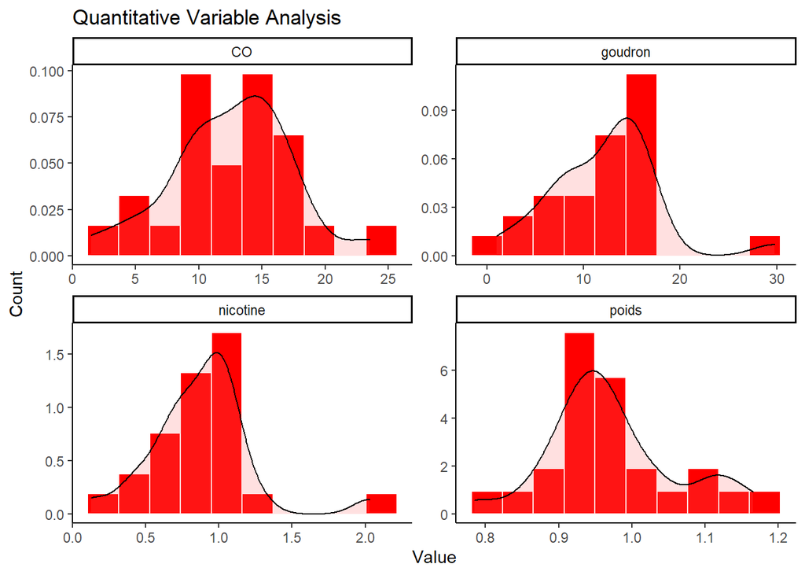

```r
histograms <- ggplot(gather(data = Ciga),aes(value)) +
  geom_histogram(aes(y=..density..),bins = 10, color = "white", fill = "red") + # Creates bin sizing and sets the lines as white
  geom_density(alpha= .2, fill="#FF6666") +
  facet_wrap(~key,scales = "free") + # Converting the graphs into panels
  ggtitle("Quantitative Variable Analysis") + # Title name
  ylab("Count") + xlab("Value") + # Label names
  theme_classic() # A classic theme, with x and y axis lines and no grid lines

histograms
```

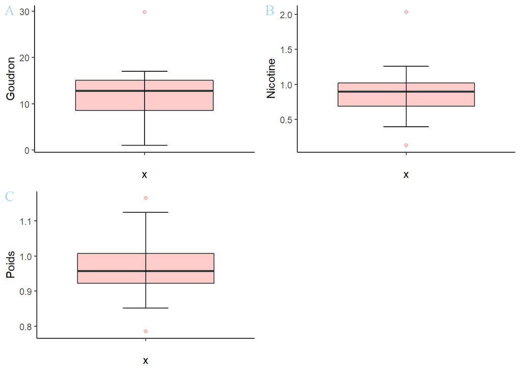

```r
# Create multiple boxplots through ggplot and various charactertics
goudron.box <- ggplot(data = Ciga, aes(x="",y= goudron)) +
    geom_boxplot(fill="red", alpha=0.2, outlier.shape = 21, outlier.color = "black") +
    stat_boxplot(geom='errorbar', linetype=1, width=0.25) +
    ylab("Goudron") + # Label names
    theme_classic() # A classic theme, no grid lines

nicotine.box <- ggplot(data = Ciga, aes(x="",y= nicotine)) +
    geom_boxplot(fill="red", alpha=0.2, outlier.shape = 21, outlier.color = "black") +
    stat_boxplot(geom='errorbar', linetype=1, width=0.25) +
    ylab("Nicotine") + # Label names
    theme_classic() # A classic theme, no grid lines

poids.box <- ggplot(data = Ciga, aes(x="",y= poids)) +
    geom_boxplot(fill="red", alpha=0.2, outlier.shape = 21, outlier.color = "black") +
    stat_boxplot(geom='errorbar', linetype=1, width=0.25) +
    ylab("Poids") + # Label names
    theme_classic() # A classic theme, no grid lines

# Designate charts to show in one space
plot_grid(goudron.box, nicotine.box, poids.box, labels = "AUTO",
  label_fontfamily = "serif",
  label_fontface = "plain",
  label_colour = "lightblue")
```

Throughout this EDA, we will primarily focus on two variable groups: explanatory (x) and response (y).

If we consider the histograms of all variables and the boxplots for the explanatory values, these values are not perfectly symmetrical. Be aware that there is no extreme deviation that can be seen within these charts. Additionally we can compare these visualizations to the analysis of the means vs medians. there are outliers present within all three explanatory variables and diving deeper, the top outliers appear to be coming from BullDurham. We will not conduct further testing as it is too early to see if those data points influence our overall results.

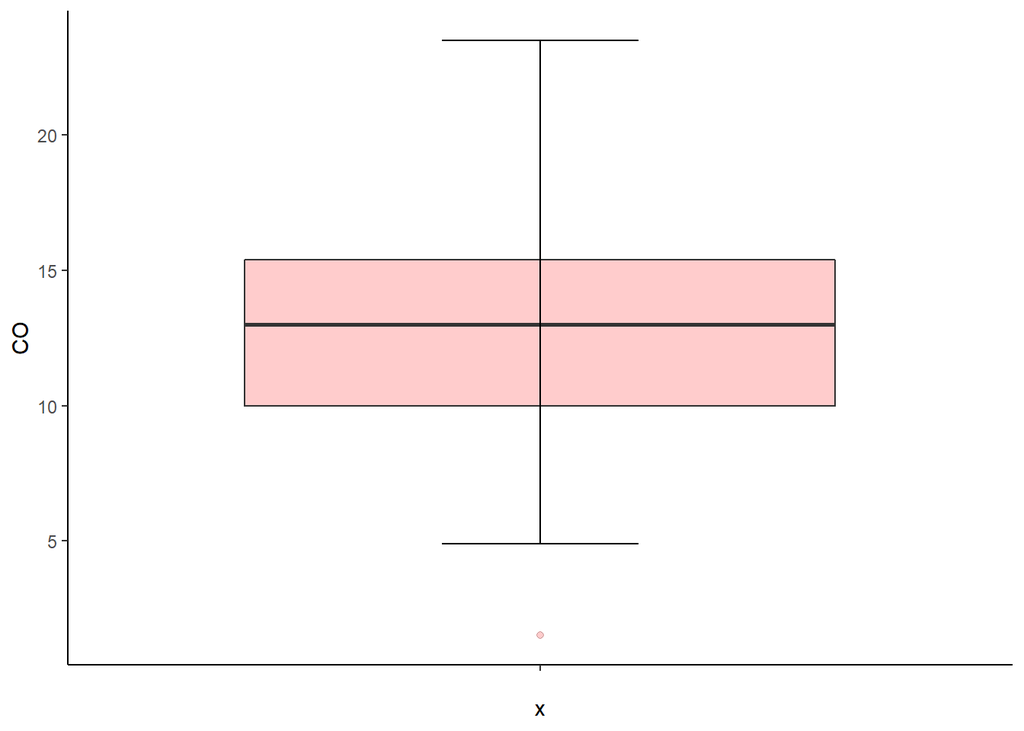

```r
# Create multiple boxplots through ggplot and various charactertics
ggplot(data = Ciga, aes(x="", y= CO)) +
    geom_boxplot(fill="red", alpha=0.2, outlier.shape = 21, outlier.color = "black") +
    stat_boxplot(geom='errorbar', linetype=1, width=0.25) +
    ylab("CO") + # Label names
    theme_classic() # A classic theme, no grid lines
```

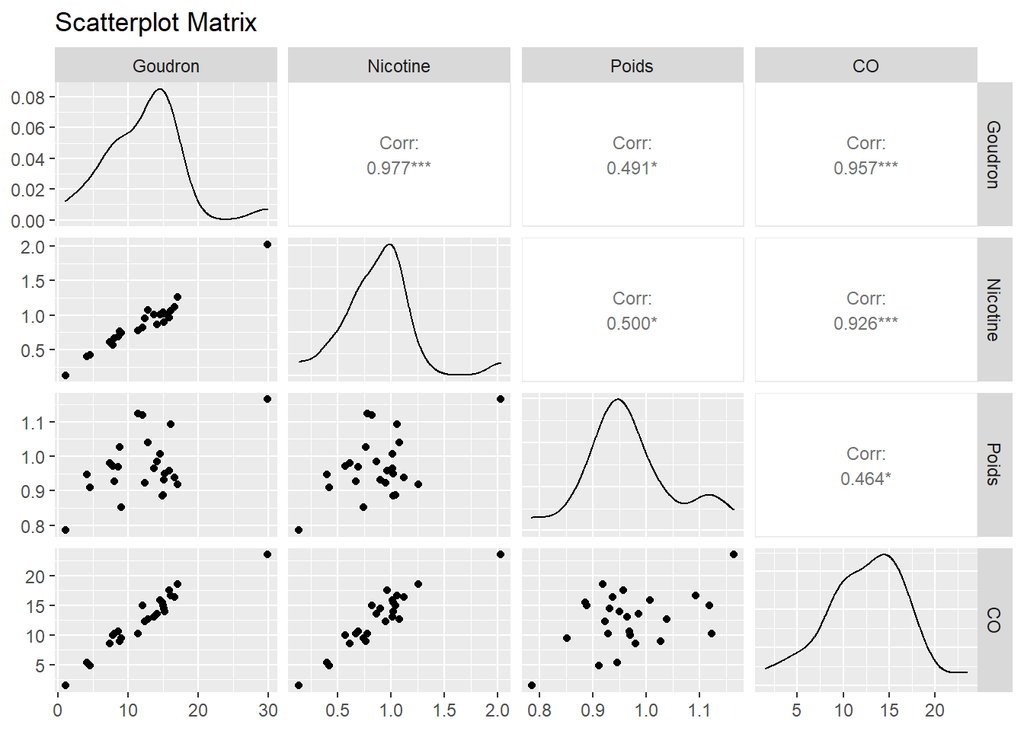

```r
# Used ggpairs to create a scatterplot matrix that includes all relevant data columns
scaterrplot <- ggpairs(Ciga, title = "Scatterplot Matrix",
                      columns = 1:4,
                      proportions = "auto",
                      columnLabels = c("Goudron","Nicotine","Poids",
                      "CO"),
                      upper = list(continuous = wrap('cor',size = 3)),)

scaterrplot
```

```r
cormat <- round(cor(Ciga),2) # Round the correlation coefficient to two decimal places

melted_cormat <- melt(cormat) # One way to reshape and elongate the data frame

# Get upper triangle of the correlation matrix
  get_upper_tri <- function(cormat){
    cormat[lower.tri(cormat)]<- NA
    return(cormat)
  }

# Rename the correlation coefficient value
upper_tri <- get_upper_tri(cormat)
upper_tri
```

```
##          goudron nicotine poids   CO
## goudron        1     0.98  0.49 0.96
## nicotine      NA     1.00  0.50 0.93
## poids         NA       NA  1.00 0.46
## CO            NA       NA    NA 1.00
```

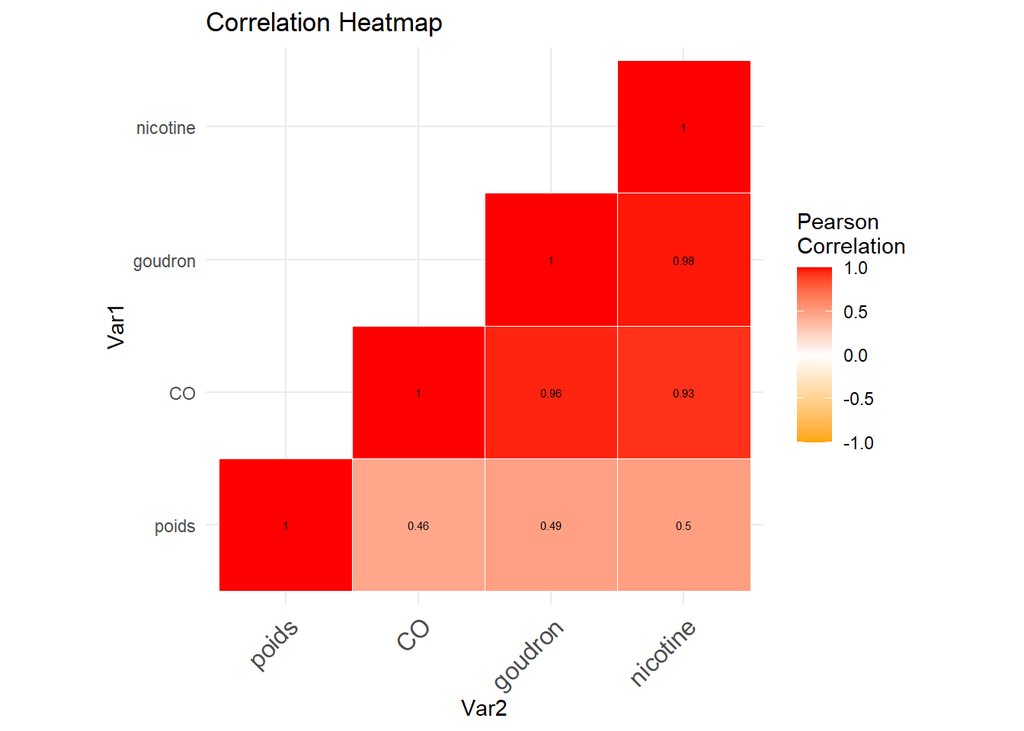

```r
# Use correlation between variables as distance
reorder_cormat <- function(cormat){
dd <- as.dist((1-cormat)/2)
hc <- hclust(dd)
cormat <-cormat[hc$order, hc$order]
}

# Reorder the correlation matrix
cormat <- reorder_cormat(cormat)
upper_tri <- get_upper_tri(cormat)

# Melt the correlation matrix
melted_cormat <- melt(upper_tri, na.rm = TRUE)

# Create a ggheatmap with multiple characteristics
ggheatmap <- ggplot(melted_cormat, aes(Var2, Var1, fill = value)) +
  geom_tile(color = "white") +
  scale_fill_gradient2(low = "orange", high = "red", mid = "white", midpoint = 0, limit = c(-1,1), space = "Lab", name="Pearson\nCorrelation") +
  ggtitle("Correlation Heatmap") + # Title name
  theme_minimal() + # Minimal theme, keeps in the lines
  theme(axis.text.x = element_text(angle = 45, vjust = 1, size = 12, hjust = 1)) +
  coord_fixed() +
  geom_text(aes(Var2, Var1, label = value), color = "black", size = 2)

# Print the heat map
print(ggheatmap)
```

There are two visuals above that show how the variables are related to one another: Scatterplot Matrix and the Correlation Heatmap. If we first consider the scatterplot graph, one would notice that there are two positively linear relationships to point out: ‘goudron’ and ‘CO’, and ‘nicotine’ and ‘CO’. Additionally, ‘goudron’ and ‘nicotine’ have a very strong correlation at 0.98. Since these two variables near 1, we have an issue with multicollinearity. To explore this further, we must look at variance inflation factors symbolized by VIF.

## Variance Inflation Factors

```r
VIF(Ciga[,1:3], Ciga[,4]) # Call VIF from sourcing
```

```
##
##  goudron nicotine    poids
## 21.63070 21.89990  1.33386
##
##   Mean: 14.9548
```

To properly analyze the results in the table above, we need to ensure that the variables to not exceed the average of VIF. Multicollinearity is present when certain VIF are larger than 5 or 10. Goudron and nicotine show signs of multicollinearity because they both exceed 10. Therefore, we will remove the variable with the highest VIF, nicotine.

```r
VIF(Ciga[,c(1,3)], Ciga[,4]) # Removed 'nicotine'
```

```
##
## goudron   poids
## 1.31726 1.31726
##
##   Mean: 1.31726
```

After removing ‘nicotine’, we no longer have a problem with multicollinearity as the mean and both variables are well under a VIF of 5.

```r
# Scatterplot on only two response variables since one was removed in a prior step
Ciga2 = Ciga [,-(2:2)]
head (Ciga2)
```

```
##   goudron  poids   CO
## 1    14.1 0.9853 13.6
## 2    16.0 1.0938 16.6
## 3    29.8 1.1650 23.5
## 4     8.0 0.9280 10.2
## 5     4.1 0.9462  5.4
## 6    15.0 0.8885 15.0
```

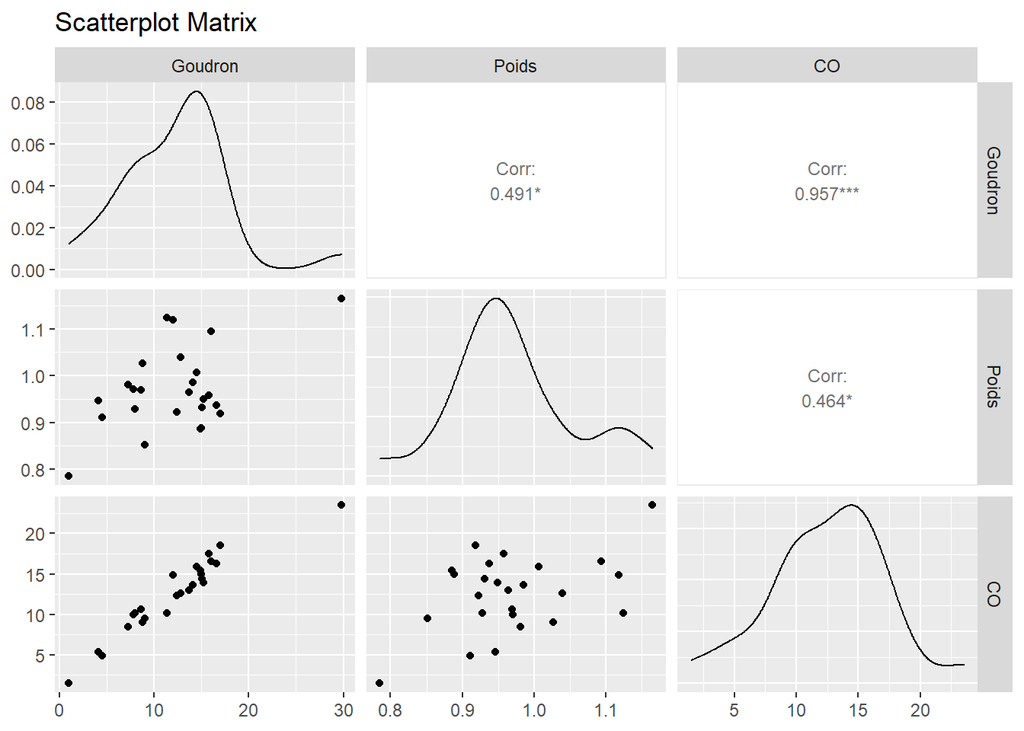

```r
scatterplot <- ggpairs(Ciga2, title = "Scatterplot Matrix",
                      columns = 1:3,
                      proportions = "auto",
                      columnLabels = c("Goudron","Poids",
                      "CO"),
                      upper = list(continuous = wrap('cor',size = 3)),)


scatterplot
```

```r
cor(Ciga2) # Check the correlations between variables
```

```
##           goudron     poids        CO
## goudron 1.0000000 0.4907654 0.9574853
## poids   0.4907654 1.0000000 0.4639592
## CO      0.9574853 0.4639592 1.0000000
```

When we have multicollinearity, there are several issues that arise:  
- The coefficient of determination R-squared is underestimated. The regressors explain the same part of the variance of the response  
- Increase in the variance of the estimators of the β coefficients. The parameters have more chances of not be significant because the corresponding variables share between them the same part of explication of the response  
- The inversion of XTX becomes impossible

We still can observe that ‘goudron’ and ‘CO’ have a positively linear relationship (correlation at 95.7%), and that are no other patterns in the data.

### Ordinary Least Squares Estimation (LS)

```r
Ciga2.ls = lm(CO ~ ., data = Ciga2) # Run a linear regression

summary(Ciga2.ls) # Look at the statisical summary
```

```
##
## Call:
## lm(formula = CO ~ ., data = Ciga2)
##
## Residuals:
##     Min      1Q  Median      3Q     Max
## -3.0865 -0.7239 -0.3684  1.0234  2.6083
##
## Coefficients:
##             Estimate Std. Error t value Pr(>|t|)
## (Intercept)  3.11433    3.41620   0.912    0.372
## goudron      0.80419    0.05904  13.622 3.36e-12 ***
## poids       -0.42287    3.81299  -0.111    0.913
## ---
## Signif. codes:  0 '***' 0.001 '**' 0.01 '*' 0.05 '.' 0.1 ' ' 1
##
## Residual standard error: 1.428 on 22 degrees of freedom
## Multiple R-squared:  0.9168, Adjusted R-squared:  0.9093
## F-statistic: 121.3 on 2 and 22 DF,  p-value: 1.318e-12
```

For the classical LS model, we will review the two explanatory variables. In the output above, the intercept and ‘poids’ are not significant as their p-values exceed α = 0.05. There is not enough evidence and therefore, we fail to reject the null hypothesis (H0: β0 = 0). Since we know that the intercept and ‘poids’ does not explain the response variable, the conclusion would be that ‘goudron’ has an effect on ‘CO’.

As we discussed in the lecture, we need to also calculate the degrees of freedom. For this exercise, we have 25 observations minus the two exploratory variables. The intercept needs to be accounted for as well, which equates to 1. To get 22 degrees of freedom, the equation would be the following: 25 - 2 - 1 = 22.

### M-estimation at 90% efficiency

```r
Ciga2.m90 = lmRob(CO ~ . , data = Ciga2) # Creates a robust model

summary(Ciga2.m90)
```

```
##
## Call:
## lmRob(formula = CO ~ ., data = Ciga2)
##
## Residuals:
##     Min      1Q  Median      3Q     Max
## -5.8013 -0.8415 -0.1418  0.9673  2.0262
##
## Coefficients:
##             Estimate Std. Error t value Pr(>|t|)
## (Intercept)  -0.4898     3.8678  -0.127    0.900
## goudron       0.9174     0.0600  15.290 3.34e-13 ***
## poids         2.1056     4.2326   0.497    0.624
## ---
## Signif. codes:  0 '***' 0.001 '**' 0.01 '*' 0.05 '.' 0.1 ' ' 1
##
## Residual standard error: 1.302 on 22 degrees of freedom
## Multiple R-Squared: 0.753
##
## Test for Bias:
##             statistic p-value
## M-estimate     1.6746  0.6426
## LS-estimate    0.9261  0.8191
```

```r
R2wRob(Ciga2.m90)
```

```
##
## lmRob with 90% efficiency (c=3.88075)
##
## Robust multiple R-squared: 0.94569, Robust adjusted R-squared: 0.937932
```

In the multiple linear regression model, the same two explanatory variables are not significant at α = 0.05. Since the p-values of the intercept and ‘poids’ are greater than alpha, we fail to reject the null hypothesis (H0: β0 = 0).

Just as before in the classical LS model, we need to calculate the degrees of freedom. For this exercise, we have 25 observations minus the two exploratory variables. The intercept needs to be accounted for as well, which equates to 1. To get 22 degrees of freedom, the equation would be the following: 25 - 2 - 1 = 22.

## Residual Analysis

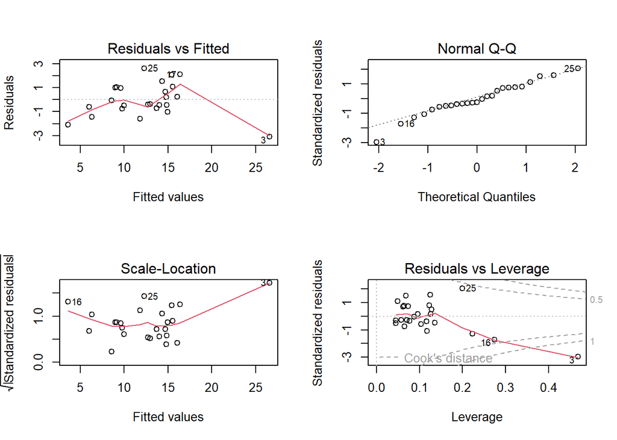

```r
par(mfrow = c(2,2))
plot(Ciga2.ls) # Plots the classical linear model
```

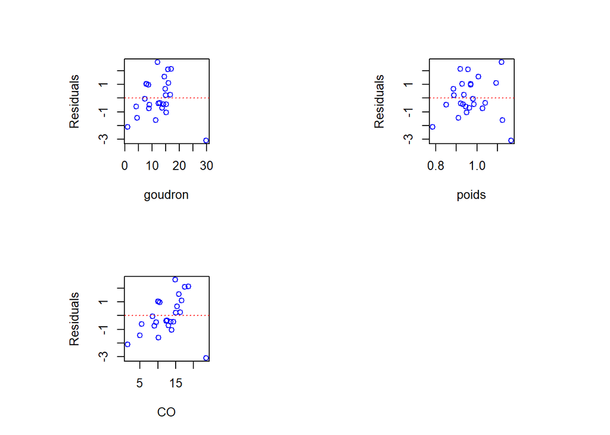

```r
par(mfrow = c(1,3))
PlotResidX(Ciga2[, 1:3], Ciga2.ls$residuals, col= "blue") # Sourcing from PlotResidx
```

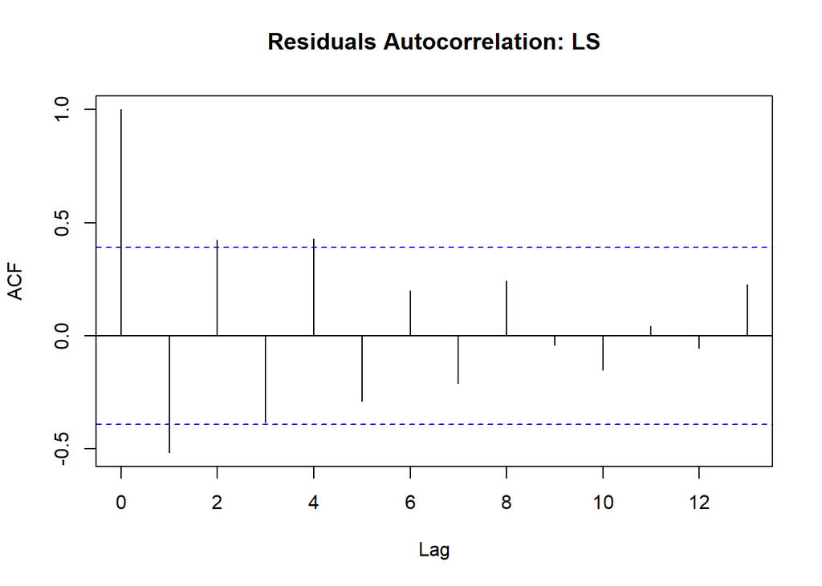

```r
# Use ACF() to create an autocorrelation, time series table
acf(resid(Ciga2.ls), main="Residuals Autocorrelation: LS")
```

**Residuals vs Fitted**  
With any model, the residuals should assume the following:  
1. ± as many negatives as positives (values), distributed around zero  
2. No structure  
3. No extreme values  
To ensure this criteria is met, we use the Residuals vs Fitted to check the lack of structure or presence of extreme values. It is important to note the following:  
- A residual will be considered large if its absolute value exceeds (approximately) 2σ(hat)  
- When n is large, a residual will be considered large if its absolute value exceeds (approximately) 4σ(hat) (otherwise, too many residues will be considered large!)

All values are weighted evenly in an LS model, including potential outliers. As mentioned above, we need to ensure that the residuals are within our limits. Referring back to the summary(Ciga2.ls) output, the model’s residual standard error is 1.428. If we multiple that value by ±2, we return our estimate. In this case, let us focus on the lower limit of 2.856. Visually, we can determine that the point ‘3’, falls outside that of -2.856 and would be considered large. Even though there is one extreme, the residuals seem to follow the other two criteria above.

**Normal Q-Q**  
To check the normality of the errors εi we do a normal Q-Q plot of the residuals. For this graph, we can use the “thickness of a pencil approach.” If we were to put the pencil on the regression line, it is immediately noticed that the data point ‘3’ is not underneath. If we did not consider that extreme value, the Q-Q plot seems to be normally distributed minus the departure at the tail part.

**Scale-Location**  
As seen in the other graphs, there is an extreme residual. We know that this is considered extreme because of the following: 2xσ.

**Residuals vs Leverage**  
The (3) outlier has a big influence as it is underneath the 1 line to the right that refers to Cook’s distance.

**Autocorrelation**  
The ACF plot shows that there is evidence of autocorrelation between the residuals as lag 1, 2, and 4 exceed the two standard error cut-off value.

From the information gathered above, we can conclude that we would not use the LS model due to it did not meeting the criteria of no extreme values and have autocorrelations of the residuals.

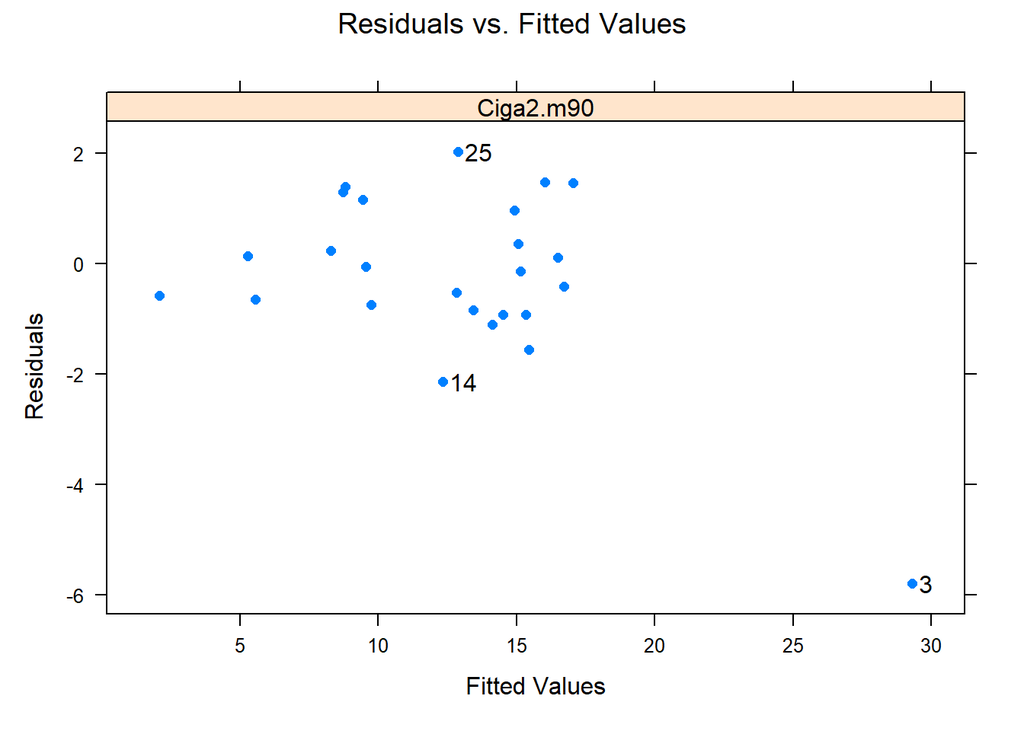

```r
plot.lmRob(Ciga2.m90, which.plots=4, id.n=10) # Review residuals
```

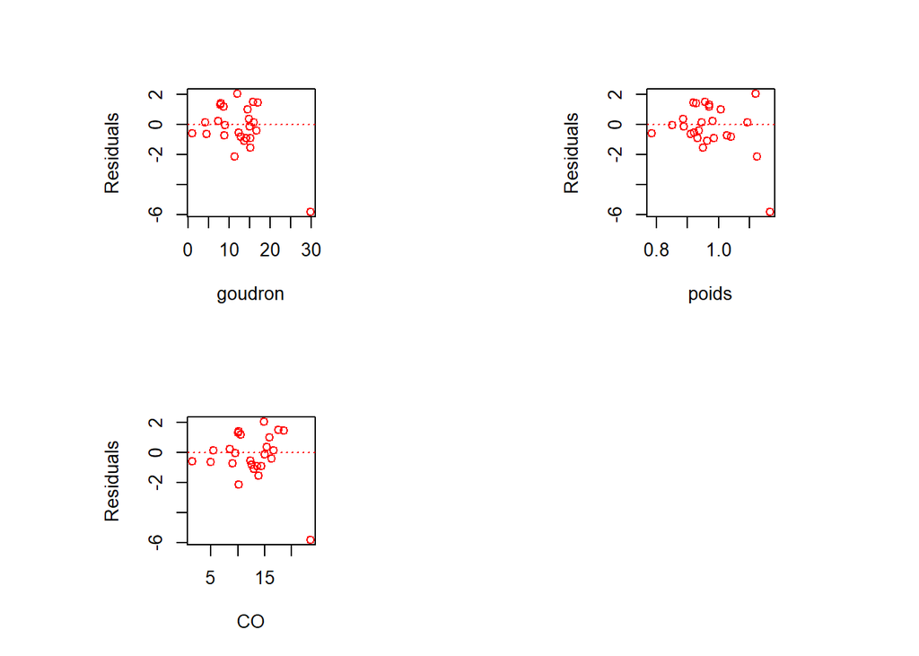

```r
par(mfrow = c(1,3)) # Puts all charts into one space
PlotResidX(Ciga2[, 1:3], Ciga2.m90$residuals, col= "red")
```

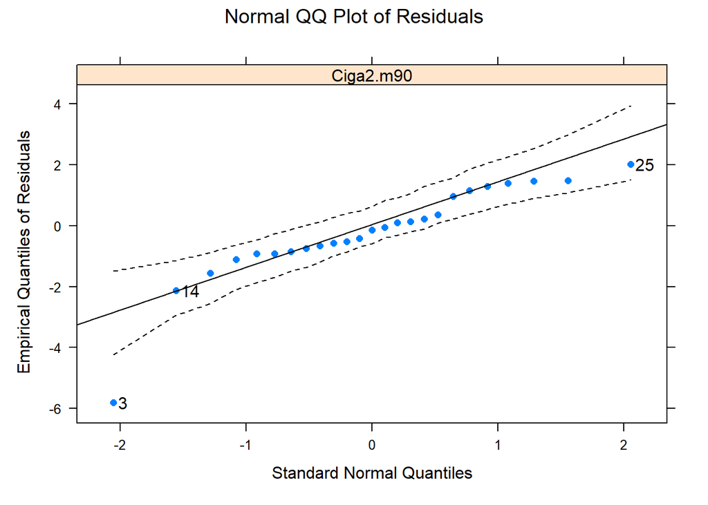

```r
plot.lmRob(Ciga2.m90, which.plots=1, id.n=10, envelope=FALSE)
```

```r
# Use lmRob() to create Q-Q plot
```

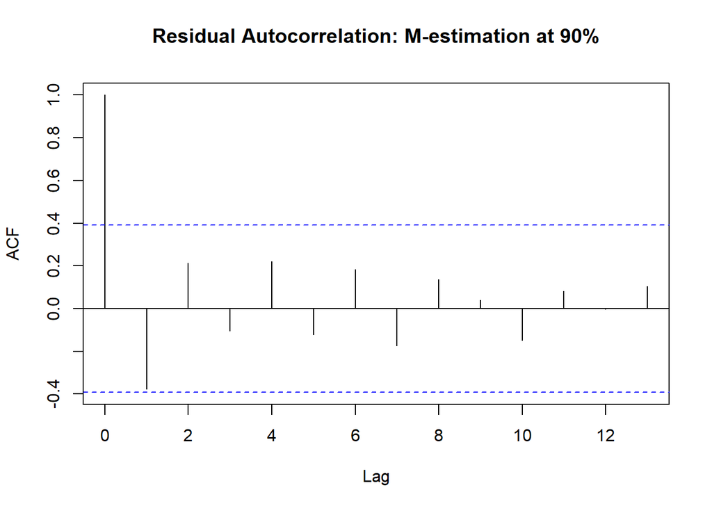

```r
# Use ACF() to create an autocorrelation, time series table
acf(resid(Ciga2.m90), main = "Residual Autocorrelation: M-estimation at 90%")
```

Unlike the classic LS model, we will say our conclusion first. Based off of the assumptions below, we will validate our M-estimation at 90% efficiency model. Here is why:

**Residuals vs Fitted**  
With any model, the residuals should assume the following:  
1. ± as many negatives as positives (values), distributed around zero  
2. No structure  
3. No extreme values  
To ensure this criteria is met, we use the Residuals vs Fitted to check the lack of structure or presence of extreme values. It is important to note the following:  
- A residual will be considered large if its absolute value exceeds (approximately) 2σ(hat)  
- When n is large, a residual will be considered large if its absolute value exceeds (approximately) 4σ(hat) (otherwise, too many residues will be considered large!)

**Normal Q-Q**  
To check the normality of the errors εi we do a normal Q-Q plot of the residuals. For this graph, we can approach the M-estimator model as we did with LS. In both situations, the extreme value is in the lower left hand corner where it departs from the tail. Otherwise, Q-Q plot seems to be normally distributed.

**Autocorrelation**  
The ACF plot shows that there is no evidence of autocorrelation between the residuals as it does not exceed the confidence interval.

As stated above, we assume that criteria are met due to the following:  
- Normal distribution (QQ plot)  
- The robust adjusted R-squared improved to 0.937932 compared to LS’ 0.9093  
- No sign of autocorrelation

## Conclusion

We need to consider which model is a better overall fit: LS or M-estimation. The following reasons indicate why one an analyst would choose one over the other:

#### Ordinary Least Squares Estimation (LS)

Advantages: efficient and unbiased estimators (in a finite sample)  
Disadvantage: model is very sensitive to deviations (i.e. extreme values) from hypothesis

#### M-estimator at 90% efficiency

From our LS analysis, we are aware of the extreme value at ‘3’. Therefore, choosing LS would not be the best method. Unlike the LS model, the resulting M-estimator is convergent, robust and the loss of efficiency is less as it can be controlled. Plus, we know that the adjusted R-squared is higher. We need to watch out for the degree of efficiency because as c decreases, the M-estimator will be more resistant to extreme values. To exemplify this, I demonstrated in Conso’s analysis how the models differ and to show how we could make a model (60% efficiency) less efficient.

**1.** *What are the estimated values for the βjs using classic (LS) and robust (M-estimation) estimation?*

| Value | LS | M at 90% |
| --- | --- | --- |
| β0 - intercept | 3.11433 | -0.4898 |
| β1 - goudron | 0.80419 | 0.9174 |
| β2 - poids | -0.42287 | 2.1056 |

**2.** *How do you interpret them?*

**OLS model**  
CO = β0 + β1(goudron) + β2(poids) CO = 3.11433 + 0.80419(goudron) - 0.42287(poids)

**M-Estimation model at 90%**  
CO = β0 + β1(goudron) + β2(poids) CO = -0.4898 + 0.9174(goudron) + 2.1056(poids)

**Interpretation**  
- Intercept (β0): The intercept contains the response variable (y). If the explanatory variables are equal to zero, the CO emission of a cigarette is equal to  
(LS): 3.11433 mg of CO and  
(M-estimation): -0.4898 mg of CO

**3.** *Are the parameters significant?*  
There is a commonality between the LS and M-estimation models. They both have ‘poids’ and the intercept that are not significant in terms of α = 0.05. This automatically means that since their p-values are higher than alpha. Therefore, we fail to reject the null hypothesis. Keeping the M-estimation model in mind, we can consider that ‘goudron’ can explain most of consumption.

**4** *How large are the R2s for your models (classic and robust)? How do you interpret them?*  
R-squared is the degree to which input variables (predictor variables) explain the variation of output variables (predicted variables). The adjusted value adjusts for predictors that are not significant in a regression model between 0 and 1. In this case, the adjusted R-squared for the classical LS model is 0.9093 and the robust model’s is at 0.937932. The R-squared shows how the regression line fits to the data. The closer to 1 the better goodness-of-fit. In this situation, the M-estimation at 90% has the higher value.

**5.** *How do you interpret the ‘Test of Bias’ results?*  
For both models, their p-values which are referenced in the ‘Test for Bias’ table show that each are higher than α = 0.05. We fail to reject the null hypothesis and there is no bias.